# BREZZA PLATANIA SALVATORE

```
Valori mancanti prima dell'imputazione:
Dosaggio (mg)                                    2
Concorrenza (n° competitors)                     1
Tipo di Farmaco (1 per generico, 0 per brand)    1
Prezzo ($)                                       0
dtype: int64

Valori mancanti dopo l'imputazione:
Dosaggio (mg)                                    0
Concorrenza (n° competitors)                     0
Tipo di Farmaco (1 per generico, 0 per brand)    0
Prezzo ($)                                       0
dtype: int64
```

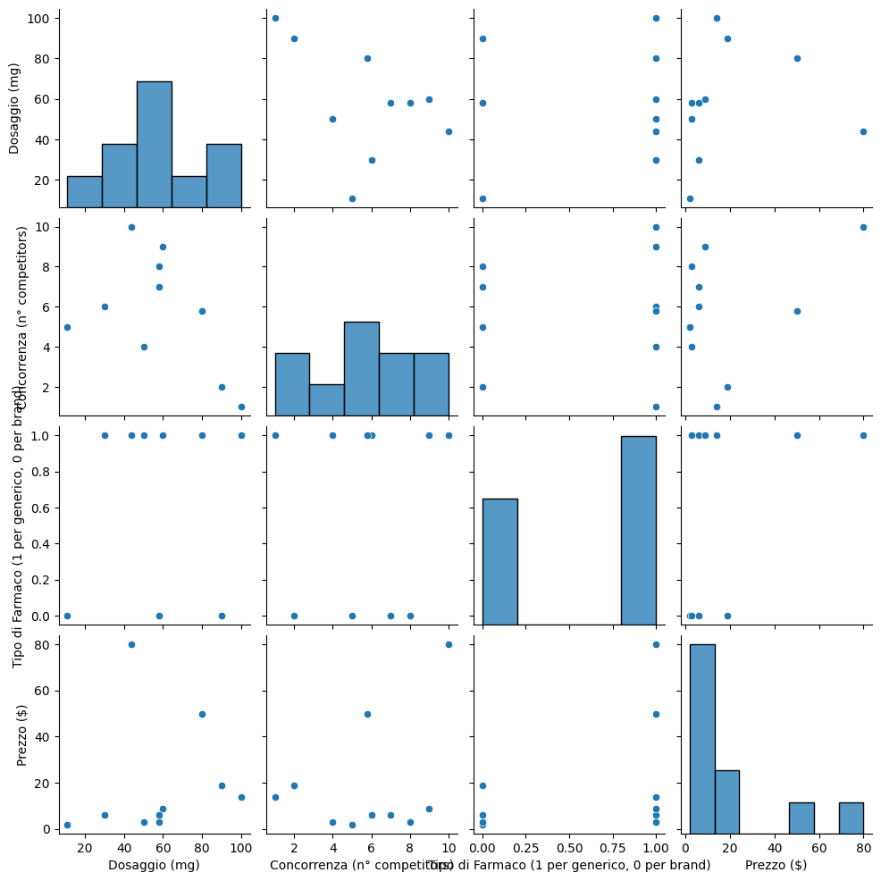

```
MSE Polinomiale: 5967.81
R² Polinomiale: -5.42
Score MSE con validazione incrociata: 36415.56

Coefficienti del modello:
                                                      Coefficient
1                                                  -5.218048e-15
Dosaggio (mg)                                       1.857813e+01
Concorrenza (n° competitors)                        9.785036e+00
Tipo di Farmaco (1 per generico, 0 per brand)       7.342249e+00
Dosaggio (mg)^2                                     7.885464e+00
Dosaggio (mg) Concorrenza (n° competitors)         -5.687702e-04
Dosaggio (mg) Tipo di Farmaco (1 per generico, ...  6.262568e+00
Concorrenza (n° competitors)^2                     -1.339396e+01
Concorrenza (n° competitors) Tipo di Farmaco (1... -2.837943e+00
Tipo di Farmaco (1 per generico, 0 per brand)^2    -3.791521e+00
```

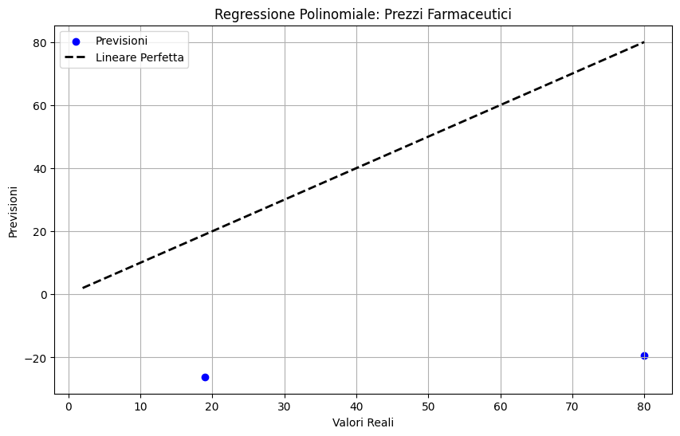

```
MSE Random Forest: 2777.76
R² Random Forest: -1.99
```

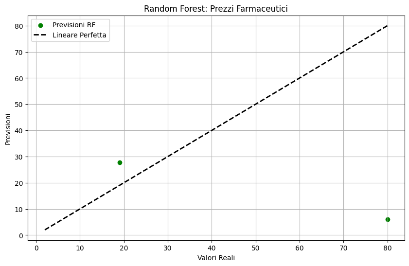

```python
# Importare le librerie necessarie
import numpy as np
import pandas as pd
import matplotlib.pyplot as plt
import seaborn as sns
from sklearn.model_selection import train_test_split, cross_val_score
from sklearn.linear_model import LinearRegression
from sklearn.preprocessing import PolynomialFeatures, StandardScaler
from sklearn.metrics import mean_squared_error, r2_score
from sklearn.pipeline import make_pipeline
from sklearn.ensemble import RandomForestRegressor

# Creare un dataset simulato con valori mancanti
data = {
    'Dosaggio (mg)': [11, 44, np.nan, 30, 50, 60, np.nan, 80, 90, 100],
    'Concorrenza (n° competitors)': [5, 10, 8, 6, 4, 9, 7, np.nan, 2, 1],
    'Tipo di Farmaco (1 per generico, 0 per brand)': [0, 1, 0, 1, np.nan, 1, 0, 1, 0, 1],
    'Prezzo ($)': [2, 80, 3, 6, 3, 9, 6, 50, 19, 14]
}

df = pd.DataFrame(data)

# Controllare se ci sono valori mancanti
print("Valori mancanti prima dell'imputazione:")
print(df.isnull().sum())

# Imputazione dei valori mancanti con la media
df['Dosaggio (mg)'] = df['Dosaggio (mg)'].fillna(df['Dosaggio (mg)'].mean())
df['Concorrenza (n° competitors)'] = df['Concorrenza (n° competitors)'].fillna(df['Concorrenza (n° competitors)'].mean())
df['Tipo di Farmaco (1 per generico, 0 per brand)'] = df['Tipo di Farmaco (1 per generico, 0 per brand)'].fillna(df['Tipo di Farmaco (1 per generico, 0 per brand)'].mode()[0])

# Controllare se ci sono ancora valori mancanti
print("\nValori mancanti dopo l'imputazione:")
print(df.isnull().sum())

# Esplorare visivamente le relazioni tra le variabili
sns.pairplot(df)
plt.show()

# Separare le feature dalla variabile target
X = df[['Dosaggio (mg)', 'Concorrenza (n° competitors)', 'Tipo di Farmaco (1 per generico, 0 per brand)']]
y = df['Prezzo ($)']

# Dividere il dataset in training e test set
X_train, X_test, y_train, y_test = train_test_split(X, y, test_size=0.2, random_state=42)

# Creare un modello di regressione polinomiale con normalizzazione
degree = 2  # Grado polinomiale
poly_model = make_pipeline(StandardScaler(), PolynomialFeatures(degree=degree), LinearRegression())
poly_model.fit(X_train, y_train)

# Fare previsioni sul test set
y_poly_pred = poly_model.predict(X_test)

# Valutare il modello
mse_poly = mean_squared_error(y_test, y_poly_pred)
r2_poly = r2_score(y_test, y_poly_pred)

# Stampa i risultati
print(f'\nMSE Polinomiale: {mse_poly:.2f}')
print(f'R² Polinomiale: {r2_poly:.2f}')

# Validazione incrociata
cv_scores = cross_val_score(poly_model, X, y, cv=5, scoring='neg_mean_squared_error')
print(f'Score MSE con validazione incrociata: {-cv_scores.mean():.2f}')

# Coefficienti del modello
linear_model = poly_model.named_steps['linearregression']
features = poly_model.named_steps['polynomialfeatures'].get_feature_names_out(X.columns)
coefficients = pd.DataFrame(linear_model.coef_, index=features, columns=["Coefficient"])
print("\nCoefficienti del modello:\n", coefficients)

# Visualizzare i risultati
plt.figure(figsize=(10, 6))
plt.scatter(y_test, y_poly_pred, color='blue', label='Previsioni')
plt.plot([y.min(), y.max()], [y.min(), y.max()], 'k--', lw=2, label='Lineare Perfetta')
plt.xlabel('Valori Reali')
plt.ylabel('Previsioni')
plt.title('Regressione Polinomiale: Prezzi Farmaceutici')
plt.legend()
plt.grid(True)
plt.show()

# Prova un modello di regressione Random Forest
rf_model = RandomForestRegressor(random_state=42)
rf_model.fit(X_train, y_train)

# Fare previsioni con Random Forest
y_rf_pred = rf_model.predict(X_test)

# Valutare il modello Random Forest
mse_rf = mean_squared_error(y_test, y_rf_pred)
r2_rf = r2_score(y_test, y_rf_pred)

print(f'\nMSE Random Forest: {mse_rf:.2f}')
print(f'R² Random Forest: {r2_rf:.2f}')

# Visualizzare i risultati per il modello Random Forest
plt.figure(figsize=(10, 6))
plt.scatter(y_test, y_rf_pred, color='green', label='Previsioni RF')
plt.plot([y.min(), y.max()], [y.min(), y.max()], 'k--', lw=2, label='Lineare Perfetta')
plt.xlabel('Valori Reali')
plt.ylabel('Previsioni')
plt.title('Random Forest: Prezzi Farmaceutici')
plt.legend()
plt.grid(True)
plt.show()
```

```python
from sklearn.model_selection import GridSearchCV

# Definire la griglia di parametri
param_grid = {
    'n_estimators': [50, 100, 200],
    'max_depth': [None, 10, 20, 30],
    'min_samples_split': [2, 5, 10],
}

# Creare il modello Random Forest
rf_model = RandomForestRegressor(random_state=42)

# Creare la ricerca degli iperparametri
grid_search = GridSearchCV(estimator=rf_model, param_grid=param_grid,
                           cv=5, scoring='neg_mean_squared_error', verbose=2, n_jobs=-1)

# Eseguire la ricerca
grid_search.fit(X_train, y_train)

# Mostrare i migliori parametri
print("Migliori parametri:", grid_search.best_params_)
```

[output not shown]

[output cut: 146 more lines]

[output not shown]

```python
# Mostrare i migliori parametri
print("Migliori parametri:", grid_search.best_params_)

# Valutare il modello finale con i migliori parametri
best_rf_model = grid_search.best_estimator_
y_best_rf_pred = best_rf_model.predict(X_test)

# Valutare il modello
mse_best_rf = mean_squared_error(y_test, y_best_rf_pred)
r2_best_rf = r2_score(y_test, y_best_rf_pred)

print(f'MSE Random Forest Ottimizzato: {mse_best_rf:.2f}')
print(f'R² Random Forest Ottimizzato: {r2_best_rf:.2f}')
```

[output not shown]

```python
from sklearn.ensemble import GradientBoostingRegressor

# Creare il modello Gradient Boosting
gb_model = GradientBoostingRegressor(random_state=42)

# Addestrare il modello
gb_model.fit(X_train, y_train)

# Fare previsioni
y_gb_pred = gb_model.predict(X_test)

# Valutare il modello
mse_gb = mean_squared_error(y_test, y_gb_pred)
r2_gb = r2_score(y_test, y_gb_pred)

print(f'MSE Gradient Boosting: {mse_gb:.2f}')
print(f'R² Gradient Boosting: {r2_gb:.2f}')
```

[output not shown]

Relazione sul Corso "Addetto alla Logistica Automatica" - Ambito IoT Introduzione Il corso "Addetto alla logistica automatica" si inserisce nel contesto dell'Internet of Things (IoT) e mira a formare professionisti in grado di gestire e ottimizzare processi logistici attraverso l'uso delle tecnologie automatizzate. Questo programma è realizzato in collaborazione con Forit Group, Politecnico Rizzo e Fomatemps, sotto l'agenzia Gi Group.

Obiettivi del Corso Formazione Teorica: Acquisire conoscenze teoriche riguardanti la logistica automatica e l'IoT. Applicazioni Pratiche: Sviluppare competenze pratiche in machine learning e intelligenza artificiale, applicandole a casi reali. Lavoro di Gruppo: Collaborare in team per risolvere problemi complessi e realizzare progetti significativi. Progetti di Machine Learning Durante il corso, abbiamo lavorato su diversi progetti di machine learning. Di seguito sono riportati alcuni esempi:

1. Predizione della Domanda Descrizione: Sviluppare un modello per prevedere la domanda di prodotti in base a variabili storiche, come vendite passate e tendenze di mercato. Tecnologie Utilizzate: Python, Scikit-learn, Pandas.
2. Ottimizzazione della Catena di Fornitura Descrizione: Implementare un modello di regressione per ottimizzare il livello di inventario in base alla domanda prevista. Tecnologie Utilizzate: Python, NumPy, Matplotlib.
3. Classificazione degli Ordini Descrizione: Creare un modello di classificazione per categorizzare gli ordini in base a variabili come la dimensione e il tipo di prodotto. Tecnologie Utilizzate: Python, Scikit-learn. Esercitazioni di Intelligenza Artificiale Abbiamo anche effettuato esercitazioni pratiche sull'intelligenza artificiale, in particolare utilizzando Python. Le attività includevano:

Introduzione a TensorFlow e Keras: Sviluppo di modelli di deep learning per la classificazione delle immagini. Progetti di Natural Language Processing (NLP): Creazione di modelli per l'analisi del sentiment e il riconoscimento di intenti. Lavoro di Gruppo Il lavoro di gruppo è stato fondamentale per il successo del corso. Attraverso la collaborazione con i compagni, abbiamo:

Condiviso Conoscenze: Abbiamo scambiato idee e strategie per affrontare le sfide comuni. Sviluppato Progetti Collaborativi: Abbiamo lavorato insieme su progetti complessi, apprendendo l'importanza della comunicazione e della cooperazione. Prossimi Passi Sviluppo Professionale: Continuare ad approfondire le conoscenze in IoT e intelligenza artificiale. Applicazioni Pratiche: Cercare opportunità di applicazione delle competenze apprese nel mondo reale, contribuendo all'innovazione nel settore della logistica.

# Sviluppo di un Programma di Intelligenza Artificiale

Durante il corso per "Addetto alla logistica automatica", ho lavorato su un progetto che prevedeva lo sviluppo di un programma di intelligenza artificiale. Grazie al supporto del docente Rizzo, abbiamo potuto analizzare e riutilizzare programmi già esistenti, concentrandoci sulla loro manutenzione e ottimizzazione. Questa esperienza mi ha permesso di approfondire le mie competenze nell'IA e di comprendere meglio le sfide associate allo sviluppo software.

# Assistenza del Docente

Durante il corso, abbiamo ricevuto supporto e guida dal docente Rizzo. La sua esperienza e conoscenza ci hanno aiutato a navigare le complessità del materiale e ad affrontare le sfide associate allo sviluppo di un software complesso.

Relazione sul Progetto di Analisi dei Prezzi Farmaceutici Introduzione L'obiettivo di questo progetto è stato sviluppare un modello di regressione per prevedere il prezzo dei farmaci basato su diverse caratteristiche, tra cui dosaggio, concorrenza e tipo di farmaco. Utilizzando tecniche di machine learning, abbiamo esplorato e implementato vari modelli, in particolare la regressione polinomiale e il modello Random Forest, al fine di migliorare l'accuratezza delle previsioni.

Dataset Abbiamo utilizzato un dataset simulato con le seguenti caratteristiche:

Dosaggio (mg) Concorrenza (n° competitors) Tipo di Farmaco (1 per generico, 0 per brand) Prezzo ($)

Il dataset conteneva inizialmente alcuni valori mancanti, che sono stati gestiti attraverso tecniche di imputazione.

Fasi del Progetto

1. Preprocessing dei Dati Controllo dei Valori Mancanti: Abbiamo verificato la presenza di valori mancanti nel dataset e abbiamo applicato tecniche di imputazione per riempire i valori vuoti. Questo è stato fatto per garantire la qualità e l'integrità dei dati prima dell'analisi.
2. Modello di Regressione Polinomiale Creazione del Modello: Abbiamo sviluppato un modello di regressione polinomiale utilizzando la libreria Scikit-learn. Questo modello è stato addestrato sui dati di addestramento e valutato su un test set.

3. Modello Random Forest Implementazione del Modello: Successivamente, abbiamo implementato un modello di Random Forest, un algoritmo di ensemble che utilizza un insieme di alberi decisionali per migliorare le previsioni.

Risultati e Discussione I risultati ottenuti dai modelli suggeriscono che ci sono opportunità di miglioramento. Le prestazioni scadenti possono essere attribuite a vari fattori, tra cui:

Qualità dei Dati: La presenza di outlier o dati inconsistenti può influenzare negativamente le previsioni. Feature Engineering: È possibile che alcune variabili non siano adeguate o che siano necessarie interazioni più complesse tra le caratteristiche. Scelta del Modello: Altri algoritmi di regressione, come il Gradient Boosting, potrebbero fornire risultati migliori. Conclusioni e Prossimi Passi Il progetto ha fornito un'interessante panoramica sull'uso di tecniche di machine learning per la previsione dei prezzi farmaceutici. Tuttavia, i risultati ottenuti indicano che è necessario un ulteriore lavoro per migliorare le prestazioni del modello.

Raccomandazioni Esplorare Altri Modelli: Considerare l'implementazione di modelli alternativi come il Gradient Boosting o le reti neurali. Analizzare i Dati: Effettuare un'analisi più approfondita per identificare outlier e migliorare la qualità dei dati. Espansione del Dataset: Raccogliere più dati per migliorare la robustezza delle previsioni